# 2015 - 2018 MLB Pitch Data Exploration

## Preliminary Wrangling

> I found this dataset on [Kaggle](https://www.kaggle.com/pschale/mlb-pitch-data-20152018). It has data on every pitch thrown in the Major League Baseball regular season from 2015 to 2018. There are 4 files which I have joined together in Merge Data jupyter notebook. The data in this dataset was gather by TrackMan. For an explanation of the columns see the [link:](https://fastballs.wordpress.com/2007/08/02/glossary-of-the-gameday-pitch-fields/)

```python
# import all packages and set plots to be embedded inline
import numpy as np
import pandas as pd
from pandas.api.types import CategoricalDtype
import matplotlib.pyplot as plt
from matplotlib.ticker import NullFormatter
from matplotlib.patches import Rectangle
import seaborn as sb
pd.set_option('display.max_columns', None)
%matplotlib inline
```

```python
df = pd.read_csv('pitch_data_merged.csv')
```

```python
df.shape
```

```
(12114, 68)
```

Since there are 2.8 million(!) rows in this data set. I will only look at one pitcher's data. I will choose [ZacK Greinke](https://www.baseball-reference.com/players/g/greinza01.shtml). He was my favorite player when we played for the Kansas City Royals. While the data from that timeframe isn't in here, it is still interesting to me. During these games he played for the Los Angels Dodgers (2015) and the Arizona Diamondbacks(2016-2018). 2015 may have been Greinke's best year as he had his lowest earned runs per 9 innings (1.66) of his career. However he only has won the Cy Young, award for the best pitcher that year, when he was with the Royals in 2009. I'm excited to analyze and visualize this data!

```python
df.head()
```

|  | ab_id | ax | ay | az | b_count | b_score | break_angle | break_length | break_y | code | end_speed | event_num | nasty | on_1b | on_2b | on_3b | outs | pfx_x | pfx_z | pitch_num | pitch_type | px | pz | s_count | spin_dir | spin_rate | start_speed | sz_bot | sz_top | … |
| --- | --- | --- | --- | --- | --- | --- | --- | --- | --- | --- | --- | --- | --- | --- | --- | --- | --- | --- | --- | --- | --- | --- | --- | --- | --- | --- | --- | --- | --- | --- |
| 0 | 2.015001e+09 | -3.588 | 28.195 | -15.663 | 0.0 | 0.0 | 9.3 | 3.9 | 23.8 | F | 82.9 | 3 | 63.0 | 0.0 | 0.0 | 0.0 | 0.0 | -2.04 | 9.34 | 1.0 | FF | 0.493 | 3.312 | 0.0 | 192.259 | 1859.083 | 90.0 | 1.60 | 3.70 | … |
| 1 | 2.015001e+09 | -6.923 | 26.911 | -13.768 | 0.0 | 0.0 | 21.5 | 3.6 | 23.8 | C | 85.4 | 4 | 40.0 | 0.0 | 0.0 | 0.0 | 0.0 | -3.73 | 9.89 | 2.0 | FF | 0.557 | 2.570 | 1.0 | 200.611 | 2117.343 | 92.1 | 1.65 | 3.76 | … |
| 2 | 2.015001e+09 | 3.657 | 25.086 | -33.934 | 0.0 | 0.0 | -6.6 | 8.9 | 23.9 | F | 79.6 | 5 | 38.0 | 0.0 | 0.0 | 0.0 | 0.0 | 2.30 | -1.15 | 3.0 | SL | 0.271 | 1.629 | 2.0 | 64.299 | 469.704 | 85.5 | 1.60 | 3.70 | … |
| 3 | 2.015001e+09 | 4.997 | 22.048 | -32.235 | 0.0 | 0.0 | -9.0 | 8.3 | 23.9 | F | 80.1 | 6 | 17.0 | 0.0 | 0.0 | 0.0 | 0.0 | 3.11 | -0.08 | 4.0 | SL | 0.011 | 2.384 | 2.0 | 89.301 | 579.285 | 85.4 | 1.60 | 3.70 | … |
| 4 | 2.015001e+09 | 5.725 | 24.080 | -29.637 | 0.0 | 0.0 | -11.3 | 7.8 | 23.9 | B | 80.8 | 7 | 37.0 | 0.0 | 0.0 | 0.0 | 0.0 | 3.51 | 1.51 | 5.0 | SL | 0.714 | 0.736 | 2.0 | 113.901 | 718.552 | 86.4 | 1.64 | 3.69 | … |

```python
print(df.describe())
```

```
              ab_id            ax            ay            az       b_count  \
count  1.211400e+04  12092.000000  12092.000000  12092.000000  12114.000000
mean   2.016614e+09     -2.272181     24.839373    -23.240086      0.846624
std    1.150260e+06      7.301390      3.392862      9.411201      0.938857
min    2.015001e+09    -24.885795      7.935621    -47.682000      0.000000
25%    2.015167e+09     -8.121313     22.651792    -30.050042      0.000000
50%    2.017016e+09     -2.129236     24.969762    -22.368484      1.000000
75%    2.018015e+09      4.420241     27.139403    -14.852153      1.000000
max    2.018181e+09     15.284000     37.339000      4.392964      3.000000

            b_score   break_angle  break_length       break_y     end_speed  \
count  12114.000000  12092.000000  12092.000000  12092.000000  12092.000000
mean       0.904408      5.686628      6.676257     23.844500     80.353076
std        1.253388     15.180223      3.553990      0.057822      5.407904
min        0.000000    -37.900000      0.400000     23.600000     47.200000
25%        0.000000     -8.900000      3.800000     23.800000     79.300000
50%        1.000000      5.400000      6.200000     23.800000     81.900000
75%        1.000000     18.600000      8.100000     23.900000     83.800000
max        8.000000    125.500000     19.500000     24.000000     88.800000

          event_num         nasty         on_1b         on_2b         on_3b  \
count  12114.000000  12092.000000  12114.000000  12114.000000  12114.000000
mean     210.350256     45.079557      0.242777      0.131336      0.063398
std      127.914231     17.231203      0.428779      0.337781      0.243687
min        3.000000      2.000000      0.000000      0.000000      0.000000
25%       97.000000     32.000000      0.000000      0.000000      0.000000
50%      210.000000     45.000000      0.000000      0.000000      0.000000
75%      315.000000     56.000000      0.000000      0.000000      0.000000
max      557.000000    100.000000      1.000000      1.000000      1.000000

               outs         pfx_x         pfx_z     pitch_num            px  \
count  12114.000000  12092.000000  12092.000000  12114.000000  12092.000000
mean       0.981922     -1.006762      4.767904      2.879974      0.057295
std        0.813646      4.723899      5.863752      1.713180      0.872055
min        0.000000    -14.996641    -12.710000      1.000000     -3.318000
25%        0.000000     -4.670000      1.307131      1.000000     -0.586711
50%        1.000000     -1.196115      5.754649      3.000000      0.092000
75%        2.000000      2.870000      9.768765      4.000000      0.710000
max        2.000000     12.532000     20.402206     13.000000      2.972577

```

[output cut: 44 more lines]

```
min        0.000000      0.000000  12715.000000          0.000000
25%        1.000000      0.000000  22382.000000          2.000000
50%        2.000000      1.000000  31149.000000          3.000000
75%        2.000000      3.000000  41290.000000          5.000000
max        3.000000     11.000000  53380.000000         11.000000

       elapsed_time  home_final_score   temperature         delay
count  12114.000000      12114.000000  12114.000000  12114.000000
mean     186.713885          3.978785     77.811705      1.934373
std       29.493031          2.789567      9.622245     14.948700
min      130.000000          0.000000     37.000000      0.000000
25%      168.000000          2.000000     73.000000      0.000000
50%      181.000000          3.000000     77.000000      0.000000
75%      201.000000          6.000000     82.000000      0.000000
max      331.000000         16.000000    103.000000    155.000000
```

### What is the structure of your dataset?

> This dataset is a series of pitch information. There are measures of what the ball is doing, who is throwing it, what happened on this play, and other factors such as weather and time.

### What is/are the main feature(s) of interest in your dataset?

> I am mainly interested to see what Greinke does with each pitch. How does he attack hitters and what are his results? This can be visualized by the spin on the ball, the speed of the ball, the movement and location.

### What features in the dataset do you think will help support your investigation into your feature(s) of interest?

> Some key variables are include: start speed, end speed, difference from start to end speed, break angle, break length, pfx_x, pfx_z, nasty, pitch type, spin rate, atbat result, pitch location/height and pitch result.

## Univariate Exploration

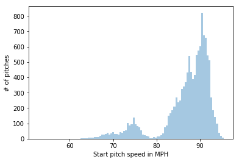

```python
sb.distplot(df.start_speed, bins = 100,  kde=False);
plt.ylabel('# of pitches');
plt.xlabel('Start pitch speed in MPH');
```

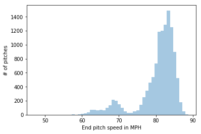

```python
sb.distplot(df.end_speed, bins = 50,  kde=False);
plt.ylabel('# of pitches');
plt.xlabel('End pitch speed in MPH');
```

This histogram looks at the distribution of the ending speed of pitches. Any kind of pitch is included. This will give the data more spread. I can look at each pitch type in a violin plot later. The distribution here looked to be somewhat normal for the first half. Once we got around 80 MPH the frequency took a huge jump. As state above, this is not that shocking.This has given me an idea to look at the difference between the start and end speed of each pitch type. I will explore this now. I will need to create a new column to do this.

```python
df['difference'] = df['start_speed'] - df['end_speed']
```

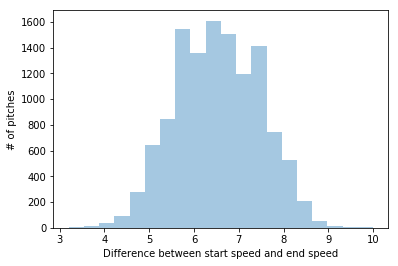

```python
sb.distplot(df.difference, bins = 20,  kde=False);
plt.ylabel('# of pitches');
plt.xlabel('Difference between start speed and end speed');
```

I will look at this more in the next section. Let's now look at spin rate.

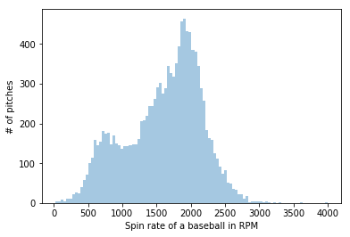

```python
sb.distplot(df.spin_rate, bins = 100,  kde=False);
plt.ylabel('# of pitches');
plt.xlabel('Spin rate of a baseball in RPM');
```

This histogram is looking at the spin rate of the pitch. Spin rates vary depending on the pitcher and pitch type. This distribution is much more smooth, but it is still not a normal distribution. We see a spike around 1800 RPM. This is a variable I will look at when looking at what affects how much a ball moves. I will keep these outliers so I can if there are any extreme effects later. I'm now going to take a look at pitch movements.

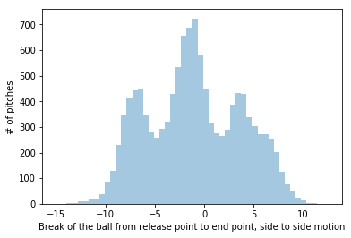

```python
sb.distplot(df.pfx_x, bins = 50, kde = False)
plt.ylabel('# of pitches')
plt.xlabel('Break of the ball from release point to end point, side to side motion');
```

This is a weird metric. It actually looks at actual movement vs expected movement (without spin). The better the pitch, due to spin, the lower the pfx_x value. A negative value means a ball with no spin induced movement will move more. A fastball will have a higher pfx_z value because backspin will cause the ball to travel, straighter, and further and not drop as much, thus a ball with no spin would have more break. This is odd, but we will look at that later. Lets look at the pfx_z value next. (Same idea just in the vertical plane)

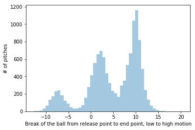

```python
sb.distplot(df.pfx_z, bins = 50, kde = False)
plt.ylabel('# of pitches')
plt.xlabel('Break of the ball from release point to end point, low to high motion');
```

This variable was explained above. We will look at the relationship beyween spin rate and these values. Speaking of pitch movement, there is this cool varriable called nasty. It measures how good of a pitch is thrown. Check it out.

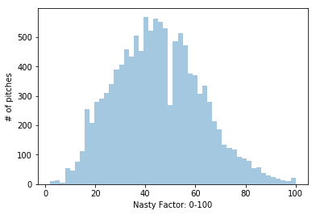

```python
sb.distplot(df.nasty, bins = 50,  kde=False);
plt.ylabel('# of pitches');
plt.xlabel('Nasty Factor: 0-100');
```

This is probably my favorite variable to look at. This gives a quick summary of every pitch metric. Pitchers and hitters shouldn't go off this, but as a fan, I think it is almost the perfect introduction to these metrics. Something with a nasty factor of 100 is near unhittable. You can see Greinke has throw a few of those. Let's get back to some more complicated metrics. Break angle is up next.

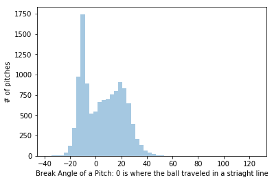

```python
sb.distplot(df.break_angle, bins = 50,  kde=False);
plt.ylabel('# of pitches');
plt.xlabel('Break Angle of a Pitch: 0 is where the ball traveled in a striaght line');
```

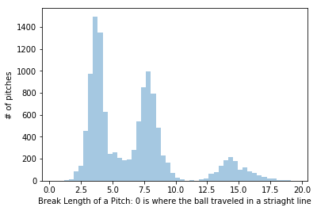

```python
sb.distplot(df.break_length, bins = 50,  kde=False);
plt.ylabel('# of pitches');
plt.xlabel('Break Length of a Pitch: 0 is where the ball traveled in a striaght line');
```

That looks a lot better. This measurement is in inches. The width of home plate is 17.5 inches. So this x axis looks correct. We see a large frequency of break length around 3 inches, again around 8, and 14.5. I think it will be interesting to compare the data points of pitches who have a break around 3,8, and 14.5. We also have the location of each pitch as it crosses the plate.

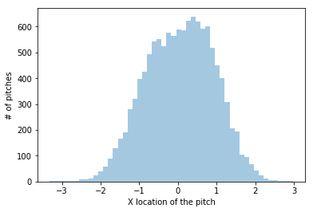

```python
sb.distplot(df.px, bins = 50,  kde=False);
plt.ylabel('# of pitches');
plt.xlabel('X location of the pitch');
```

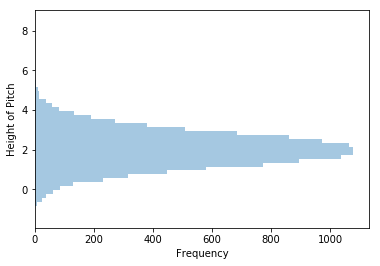

```python
sb.distplot(df.pz, bins = 50,  kde=False, vertical = True);
plt.ylabel('Height of Pitch');
plt.xlabel('Frequency');
```

These distributions look the most normal. The scale is in feet. The plate is 17.5 inches wide. 0 on the x-axis is right down the middle. The height is a bit more subjective to the batter, the strike zone is relative to the player's height. However, 1.5 and 3.5 are good estimates for the bottom and top of the zone. I love to plot this and look at the location of pitches. We an look at this later. Let's look at the result of each pitch.

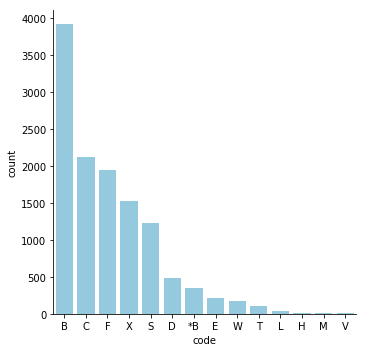

```python
sb.catplot(data = df, x = 'code', kind = 'count', order = df.code.value_counts().index, color = 'skyblue');
```

The encodings are a little odd. Lucky, Kaggle has information on these values. See below:

B - Ball

*B - Ball in dirt

S - Swinging Strike

C - Called Strike

F - Foul

T - Foul Tip

L - Foul Bunt

W - Swinging Strike (Blocked)

M - Missed Bunt

P - Pitchout

Q - Swinging pitchout

R - Foul pitchout

Values that only occur on last pitch of at-bat:

X - In play, out(s)

D - In play, no out

E - In play, runs

H - Hit by pitch

*I haven't been able to find what 'V' means*

This is a really cool pitch by pitch result. I'd like to look into this more. These encodings are messy. Lets rename to the given definiton above.

```python
df.code = df.code.replace({ 'B' : 'Ball',
                           '*B' : 'Ball in dirt',
                           'S' : 'Swinging Strike',
                           'C' : 'Called Strike',
                           'F' : 'Foul',
                           'T' : 'Foul Tip',
                           'L' : 'Foul Bunt',
                           'W' : 'Swinging Strike(Blocked)',
                           'M' : 'Missed Bunt',
                           'P' : 'Pitchout',
                           'Q' : 'Swinging pitchout',
                           'R' : 'Foul pitchout',
                           'X' : 'In play, out(s)',
                           'D' : 'In play, no out',
                           'E' : 'In play, runs',
                           'H' : 'Hit by pitch',})
```

```python
df.head()
```

|  | ab_id | ax | ay | az | b_count | b_score | break_angle | break_length | break_y | code | end_speed | event_num | nasty | on_1b | on_2b | on_3b | outs | pfx_x | pfx_z | pitch_num | pitch_type | px | pz | s_count | spin_dir | spin_rate | start_speed | sz_bot | sz_top | … |
| --- | --- | --- | --- | --- | --- | --- | --- | --- | --- | --- | --- | --- | --- | --- | --- | --- | --- | --- | --- | --- | --- | --- | --- | --- | --- | --- | --- | --- | --- | --- |
| 0 | 2.015001e+09 | -3.588 | 28.195 | -15.663 | 0.0 | 0.0 | 9.3 | 3.9 | 23.8 | Foul | 82.9 | 3 | 63.0 | 0.0 | 0.0 | 0.0 | 0.0 | -2.04 | 9.34 | 1.0 | FF | 0.493 | 3.312 | 0.0 | 192.259 | 1859.083 | 90.0 | 1.60 | 3.70 | … |
| 1 | 2.015001e+09 | -6.923 | 26.911 | -13.768 | 0.0 | 0.0 | 21.5 | 3.6 | 23.8 | Called Strike | 85.4 | 4 | 40.0 | 0.0 | 0.0 | 0.0 | 0.0 | -3.73 | 9.89 | 2.0 | FF | 0.557 | 2.570 | 1.0 | 200.611 | 2117.343 | 92.1 | 1.65 | 3.76 | … |
| 2 | 2.015001e+09 | 3.657 | 25.086 | -33.934 | 0.0 | 0.0 | -6.6 | 8.9 | 23.9 | Foul | 79.6 | 5 | 38.0 | 0.0 | 0.0 | 0.0 | 0.0 | 2.30 | -1.15 | 3.0 | SL | 0.271 | 1.629 | 2.0 | 64.299 | 469.704 | 85.5 | 1.60 | 3.70 | … |
| 3 | 2.015001e+09 | 4.997 | 22.048 | -32.235 | 0.0 | 0.0 | -9.0 | 8.3 | 23.9 | Foul | 80.1 | 6 | 17.0 | 0.0 | 0.0 | 0.0 | 0.0 | 3.11 | -0.08 | 4.0 | SL | 0.011 | 2.384 | 2.0 | 89.301 | 579.285 | 85.4 | 1.60 | 3.70 | … |
| 4 | 2.015001e+09 | 5.725 | 24.080 | -29.637 | 0.0 | 0.0 | -11.3 | 7.8 | 23.9 | Ball | 80.8 | 7 | 37.0 | 0.0 | 0.0 | 0.0 | 0.0 | 3.51 | 1.51 | 5.0 | SL | 0.714 | 0.736 | 2.0 | 113.901 | 718.552 | 86.4 | 1.64 | 3.69 | … |

The event is always for the last pitch in the at bat. When I merged the dataset, the event got stuck with every pitch of the at bat. I'm going to drop ab_id duplicates and keep the last one.

```python
dfEvent = df.drop_duplicates( subset = 'ab_id', keep = 'last', inplace = False)
```

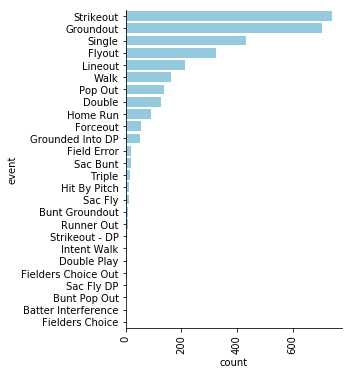

```python
sb.catplot(data = dfEvent, y = 'event', kind = 'count', order = dfEvent.event.value_counts().index, color = 'skyblue');
plt.xticks(rotation= '90');
```

This is a pretty cool distributions of the results of batters when they face Greinke. I told you he was a pretty good pitcher, and the most common results for batters is a strikeout. That's impressive. I want to look at the frequency of each pitch type now.

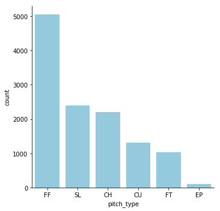

```python
sb.catplot(data = df, x = 'pitch_type', kind = 'count', order = df.pitch_type.value_counts().index, color = 'skyblue');
```

This graph shows the amount of pitch types in our data. Here are what the variable names mean:

FF - Four-seam Fastball

SL - Slider

CH - Changeup

CU - Curveball

FT - Two-seam Fastball

EP - Eephus*

*these pitch types occur rarely,

We see that four seem fastballs and sliders are throw the most often. Greinke throws an eephus, which is an odd pitch. Here is a [video](https://www.youtube.com/watch?v=1yIUz4JSaAE). It is such a slow pitch and drops a lot. My favorite is around 40 seconds. The hitters are often completely baffled by it.

For a decent explanation of each pitch check out my [blog post](https://andrewschutte.blogspot.com/2019/03/mlb-pitch-data-2015-2018.html)

### Discuss the distribution(s) of your variable(s) of interest. Were there any unusual points? Did you need to perform any transformations?

> These distributions area little odd. They have a few different peaks. This is mainly due to the variable, pitch type. We will explore that later. I didn't need to clean much up. I believe everything can be explained by looking at other variables.

### Of the features you investigated, were there any unusual distributions? Did you perform any operations on the data to tidy, adjust, or change the form of the data? If so, why did you do this?

> I did turn some columns into the category data type. This helped me create a diagram. I didn't have to do much other cleaning. When I used the full dataset for personal projects, there is a lot of cleaning and outliers I have to deal with. I did create a new column which finds the pitch speed difference from release to home plate. I will also define my categories and their orders

```python
eve = dfEvent.event.value_counts().index
code = df.code.value_counts().index
pi_type = CategoricalDtype(categories=["FF","FT","SL" ,"CH", "CU", "EP"],ordered=True)
ev_type = CategoricalDtype(categories=eve, ordered=True)
co_type = CategoricalDtype(categories=code, ordered=True)
```

```python
dfEvent.pitch_type = dfEvent.pitch_type.astype(pi_type)
df.pitch_type = df.pitch_type.astype(pi_type)
dfEvent.event = dfEvent.event.astype(ev_type)
df.code = df.code.astype(co_type)
```

## Bivariate Exploration

I'm going to be looking at how the movement variables relate to each other.

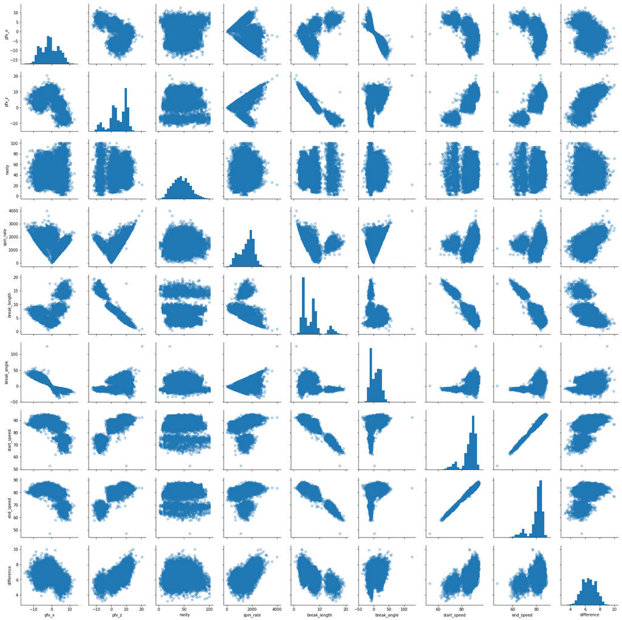

```python
g = sb.PairGrid(data = df, vars = ['pfx_x', 'pfx_z', 'nasty','spin_rate', 'break_length', 'break_angle', 'start_speed', 'end_speed', 'difference'])
g = g.map_diag(plt.hist, bins = 20);
g.map_offdiag(plt.scatter, alpha = 0.3);
```

Let's talk about what we see here. Some of the scatter plots show almost no correlation, but there are some indications of variables having an effect. Some plots have two or three main blows of data points. This is most likely due to the different pitch type Greinke throws. I will continue to look at different pitch types and how the metrics change.

Another observation here is that some plots have what looks like a 'V' in them. This again is most likely due to the fact that we have another variable effecting this.

I now want to look at the relationship pitch type and spin rate, start, end, and difference in speed.

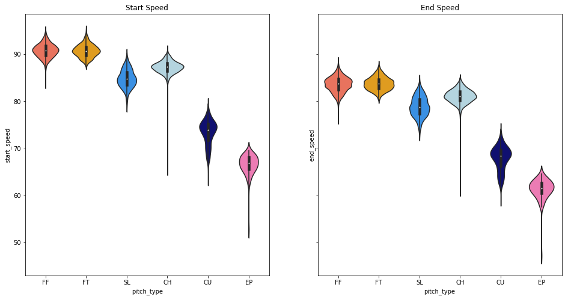

```python
fig, ax = plt.subplots(1,2, figsize = [16,8], sharey='row')
ax = ax.flatten()

ax1 = sb.violinplot(data = df, x = 'pitch_type', y = 'start_speed', palette = ['tomato', 'orange','dodgerblue','lightblue','navy', 'hotpink'], ax=ax[0])
ax2 = sb.violinplot(data = df, x = 'pitch_type', y = 'end_speed',  palette = ['tomato', 'orange','dodgerblue','lightblue','navy', 'hotpink'], ax=ax[1])

ax1.title.set_text('Start Speed')
ax2.title.set_text('End Speed')
```

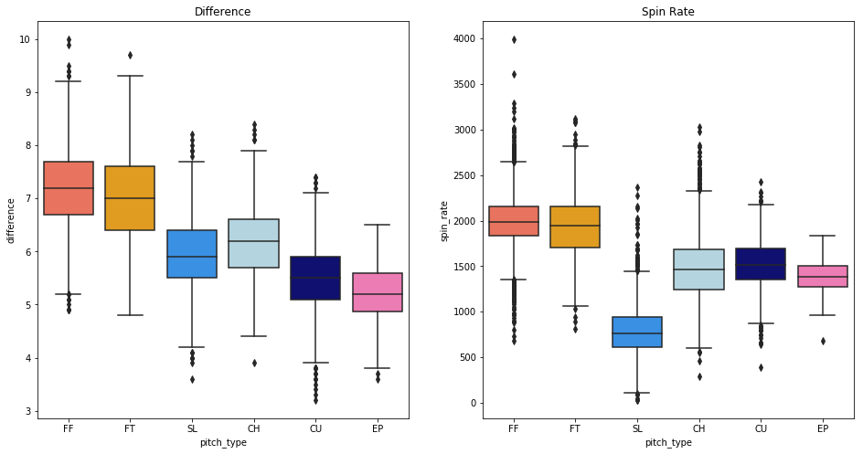

```python
fig, ax = plt.subplots(1,2, figsize = [16,8])
ax = ax.flatten()
ax1 = sb.boxplot(data = df, x = 'pitch_type', y = 'difference', ax=ax[0], palette = ['tomato', 'orange','dodgerblue','lightblue','navy', 'hotpink'])
ax2 = sb.boxplot(data = df, x = 'pitch_type', y = 'spin_rate', ax=ax[1], palette = ['tomato', 'orange','dodgerblue','lightblue','navy', 'hotpink'])
ax1.title.set_text('Difference')
ax2.title.set_text('Spin Rate')
```

Here, I split my visualizations into two different subplots. The main reasoning behind this was so I could have my start and end speed axes be equal and the difference and spin rate plots would have their own unique axes. I think these plots look really good. It is easy to tell which pitches are the fastest and which pitches have the greatest difference in start and end speed. This tells us a lot about Greinke's pitches from a physics stand point. I want to know how he uses these pitches.

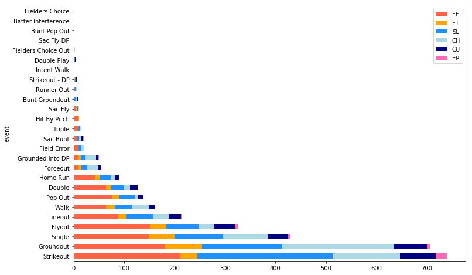

```python
c = pd.crosstab(dfEvent['event'], dfEvent['pitch_type'])
#c.sort_values(by = dfEvent.event,ascending=False)
ax = c.plot.barh(stacked=True,  figsize=(12,8),color = ['tomato', 'orange','dodgerblue','lightblue','navy', 'hotpink'])
ax.legend(bbox_to_anchor=(1,1));
plt.show()
```

This stacked bar chart shows the, a) frequency of each event by total bar length , and b) shows the total number of each pitch type used to achieve this in event. This graph can be deceiving since it is showing totals instead of percentages. Let's see those percentages and see what conclusions we can draw.

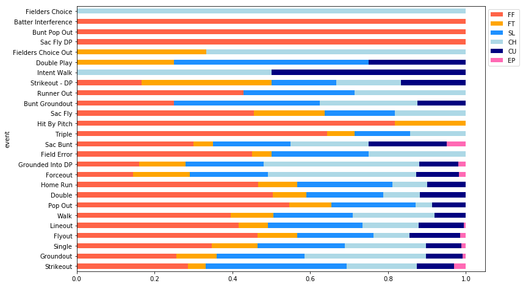

```python
p_table = pd.pivot_table(dfEvent,index='event',columns='pitch_type',aggfunc='size')
p_table = p_table.div(p_table.sum(axis=1), axis=0)
ax = p_table.plot.barh(stacked=True, figsize=(12,8), color = ['tomato', 'orange','dodgerblue','lightblue','navy', 'hotpink'])
ax.legend(bbox_to_anchor=(1,1));
```

This is also a stacked bar chart, but this shows the percentages of the total.This was difficult, I used this for [help](https://www.reddit.com/r/learnpython/comments/4s16wh/help_with_a_stacked_bar_chart/). Every event length is 1, or 100%, and the length of the colored bars is the percent of each pitch per event. Here are some conclusions I came up with:

- Greinke strikes out the most people with this four seam fastball and slider
- He uses his change up to get ground ball outs and force outs
- Grenike will hit batters with either his four seam or two seam fastball
- Batters are able to hit his four seam fastball pretty well as he has given up triples the most on that pitch.
- The eephus is not throw that often, but it is rare for a batter to hit that pitch well.

Let's look at the encoding of each pitch. This is much more general and we will look at all pitches from Grienke.

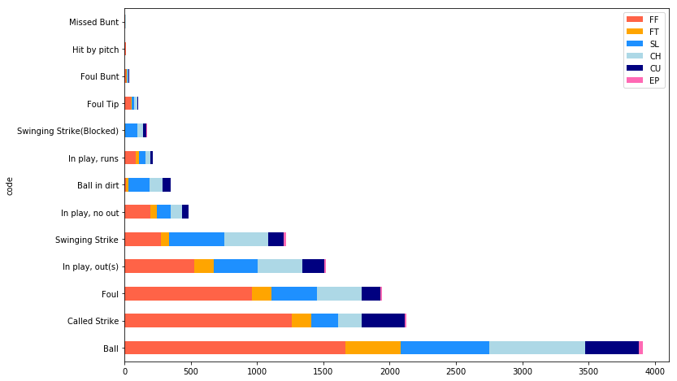

```python
c = pd.crosstab(df['code'], df['pitch_type'])
#c.sort_values(by = dfEvent.event,ascending=False)
ax = c.plot.barh(stacked=True,  figsize=(12,8),color = ['tomato', 'orange','dodgerblue','lightblue','navy', 'hotpink'])
ax.legend(bbox_to_anchor=(1,1));
plt.show()
```

This shows us the amount of each pitch result and how many pitches lead to this result. This can be slightly deceiving when looking at which pitches should be tied to each result. Instead a percentage of the pitch amount vs total amount of results would be better. Look at this below.

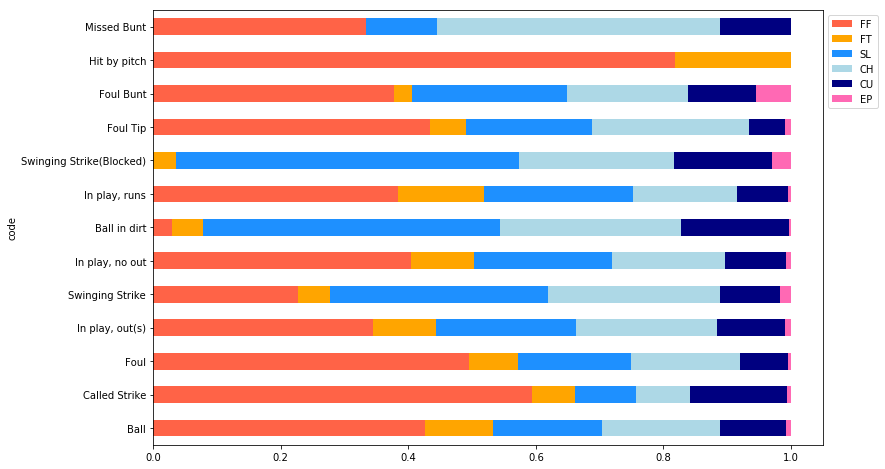

```python
p_table = pd.pivot_table(df,index='code',columns='pitch_type',aggfunc='size')
p_table = p_table.div(p_table.sum(axis=1), axis=0)
ax = p_table.plot.barh(stacked=True, figsize=(12,8), color = ['tomato', 'orange','dodgerblue','lightblue','navy', 'hotpink'])
ax.legend(bbox_to_anchor=(1,1));
```

This is much better view. Here are some observations:

- Four Seam Fastballs are called strikes more often than any other pitch
- Greinke gets a lot of swing and misses on Sliders and Change Ups.
- Greinke gets a lot of swinging strikes(blocked) or in the dirt on his Slider.
- He also throws that pitch in the dirt a lot. This is probably a case where he hopes he can get the opponent to swing and miss at them
- The Two Seam Fastball seems to be his worst pitch. It gets hit in play and isn't an out more often than any other type of result for that pitch.

I mentioned the nasty factor earlier. I want to look at that vs spin rate.

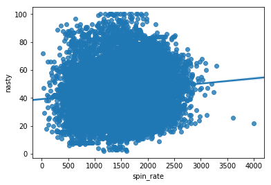

```python
sb.regplot(df.spin_rate, df.nasty)
```

Doesn't seem like much of a correlation. What if we broke it down by pitch type?

```python
ff =df.query('pitch_type == "FF"')
sl =df.query('pitch_type == "SL"')
ch =df.query('pitch_type == "CH"')
cu =df.query('pitch_type == "CU"')
ft =df.query('pitch_type == "FT"')
ep =df.query('pitch_type == "EP"')
```

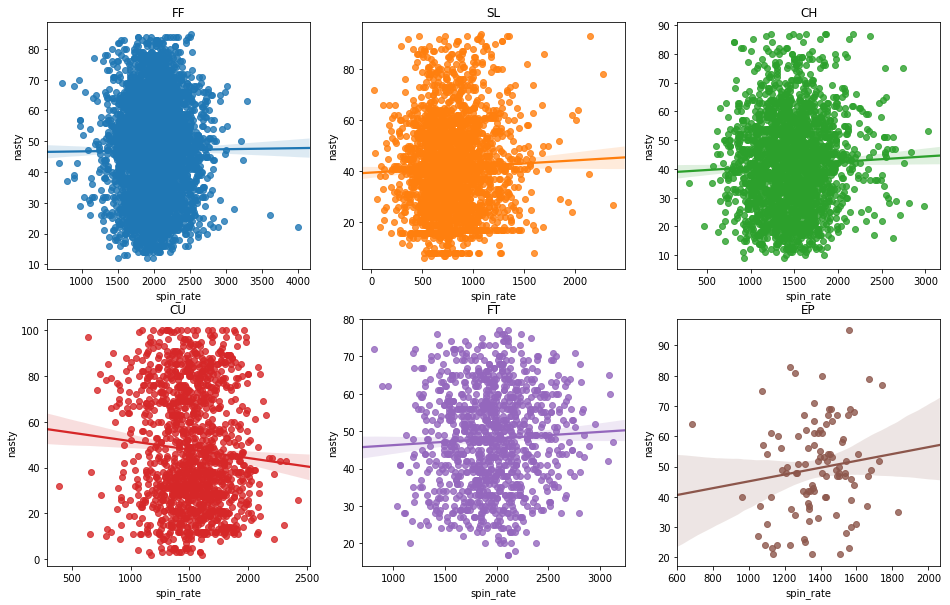

```python
fig, ax = plt.subplots(2,3, figsize = [16,10])

ax = ax.flatten()
ax0 =sb.regplot(data = ff, y = 'nasty', x = 'spin_rate', ax= ax[0])
ax1 =sb.regplot(data = sl, y = 'nasty', x = 'spin_rate', ax= ax[1])
ax2 =sb.regplot(data = ch, y = 'nasty', x = 'spin_rate', ax= ax[2])
ax3 =sb.regplot(data = cu, y = 'nasty', x = 'spin_rate', ax= ax[3])
ax4 =sb.regplot(data = ft, y = 'nasty', x = 'spin_rate', ax= ax[4])
ax5 =sb.regplot(data = ep, y = 'nasty', x = 'spin_rate', ax= ax[5])
ax0.title.set_text('FF')
ax1.title.set_text('SL')
ax2.title.set_text('CH')
ax3.title.set_text('CU')
ax4.title.set_text('FT')
ax5.title.set_text('EP');
```

Well this is a little disappointing. There doesn't seem to be a correlation. I'm going to look at difference, pfx_x, pfx_z vs nasty per pitch type.

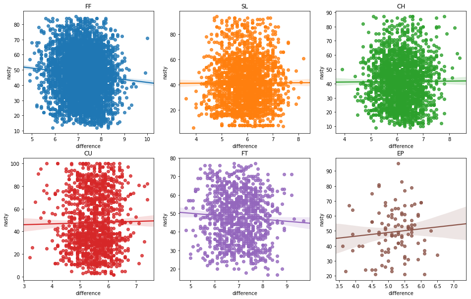

```python
fig, ax = plt.subplots(2,3, figsize = [16,10])

ax = ax.flatten()
ax0 =sb.regplot(data = ff, y = 'nasty', x = 'difference', ax= ax[0])
ax1 =sb.regplot(data = sl, y = 'nasty', x = 'difference', ax= ax[1])
ax2 =sb.regplot(data = ch, y = 'nasty', x = 'difference', ax= ax[2])
ax3 =sb.regplot(data = cu, y = 'nasty', x = 'difference', ax= ax[3])
ax4 =sb.regplot(data = ft, y = 'nasty', x = 'difference', ax= ax[4])
ax5 =sb.regplot(data = ep, y = 'nasty', x = 'difference', ax= ax[5])
ax0.title.set_text('FF')
ax1.title.set_text('SL')
ax2.title.set_text('CH')
ax3.title.set_text('CU')
ax4.title.set_text('FT')
ax5.title.set_text('EP');
```

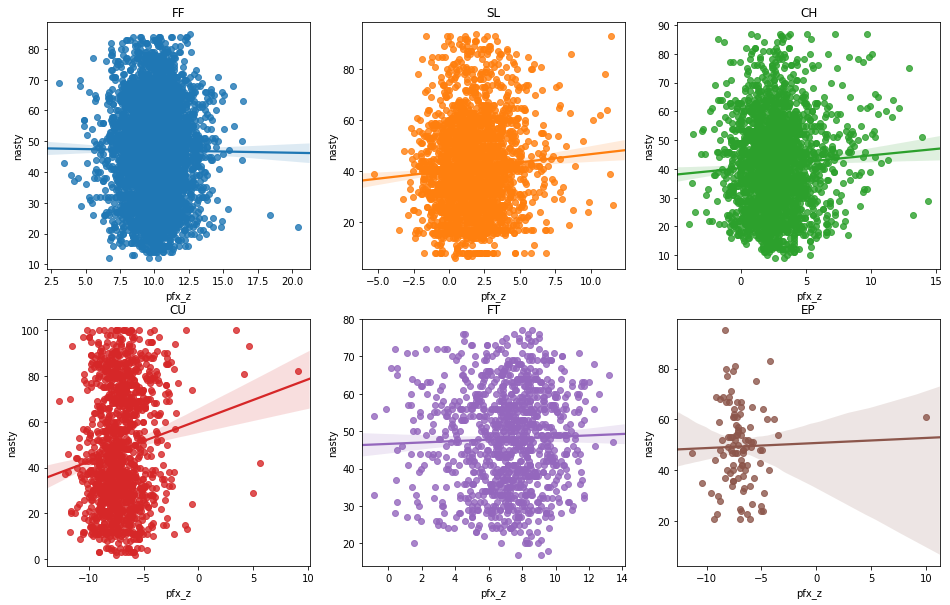

```python
fig, ax = plt.subplots(2,3, figsize = [16,10])

ax = ax.flatten()
ax0 =sb.regplot(data = ff, y = 'nasty', x = 'pfx_z', ax= ax[0])
ax1 =sb.regplot(data = sl, y = 'nasty', x = 'pfx_z', ax= ax[1])
ax2 =sb.regplot(data = ch, y = 'nasty', x = 'pfx_z', ax= ax[2])
ax3 =sb.regplot(data = cu, y = 'nasty', x = 'pfx_z', ax= ax[3])
ax4 =sb.regplot(data = ft, y = 'nasty', x = 'pfx_z', ax= ax[4])
ax5 =sb.regplot(data = ep, y = 'nasty', x = 'pfx_z', ax= ax[5])
ax0.title.set_text('FF')
ax1.title.set_text('SL')
ax2.title.set_text('CH')
ax3.title.set_text('CU')
ax4.title.set_text('FT')
ax5.title.set_text('EP');
```

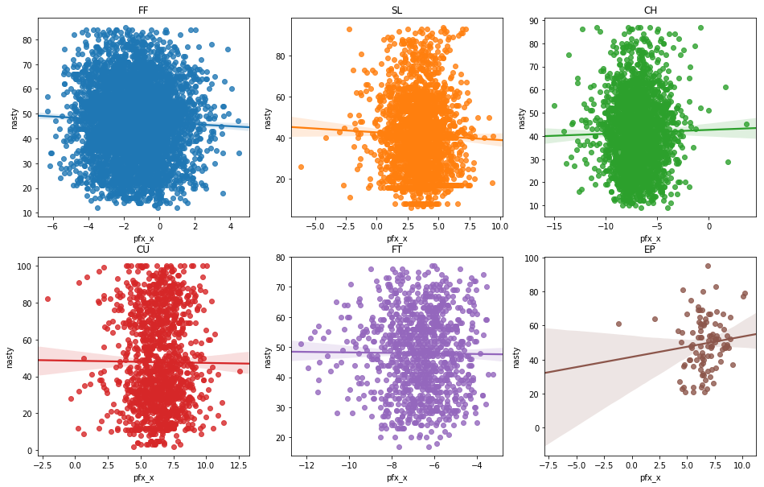

```python
fig, ax = plt.subplots(2,3, figsize = [16,10])

ax = ax.flatten()
ax0 =sb.regplot(data = ff, y = 'nasty', x = 'pfx_x', ax= ax[0])
ax1 =sb.regplot(data = sl, y = 'nasty', x = 'pfx_x', ax= ax[1])
ax2 =sb.regplot(data = ch, y = 'nasty', x = 'pfx_x', ax= ax[2])
ax3 =sb.regplot(data = cu, y = 'nasty', x = 'pfx_x', ax= ax[3])
ax4 =sb.regplot(data = ft, y = 'nasty', x = 'pfx_x', ax= ax[4])
ax5 =sb.regplot(data = ep, y = 'nasty', x = 'pfx_x', ax= ax[5])
ax0.title.set_text('FF')
ax1.title.set_text('SL')
ax2.title.set_text('CH')
ax3.title.set_text('CU')
ax4.title.set_text('FT')
ax5.title.set_text('EP');
```

Wow, so none of those worked. There has to be something. Lets add another 2 variables. px and pz. These represent the location of the pitch, in feet as it crosses the plate. Let's check out two more plots before we move on, break_length and break_angle vs spin rate by pitch type

Here is a picture that explains both of these more:

[figure not shown]

This shows the pitch movement from above. The left is the release point and right is where it crosses home plate/is measured.

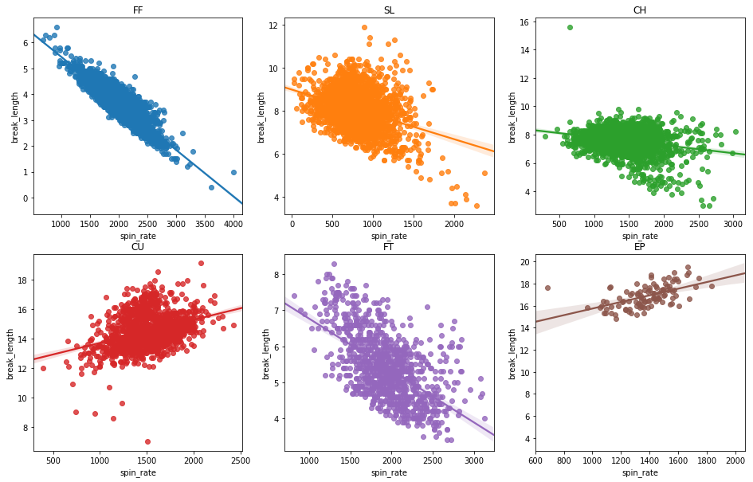

```python
fig, ax = plt.subplots(2,3, figsize = [16,10])

ax = ax.flatten()

ax0 =sb.regplot(data = ff, y = 'break_length', x = 'spin_rate', ax= ax[0])
ax1 =sb.regplot(data = sl, y = 'break_length', x = 'spin_rate', ax= ax[1])
ax2 =sb.regplot(data = ch, y = 'break_length', x = 'spin_rate', ax= ax[2])
ax3 =sb.regplot(data = cu, y = 'break_length', x = 'spin_rate', ax= ax[3])
ax4 =sb.regplot(data = ft, y = 'break_length', x = 'spin_rate', ax= ax[4])
ax5 =sb.regplot(data = ep, y = 'break_length', x = 'spin_rate', ax= ax[5])
ax0.title.set_text('FF')
ax1.title.set_text('SL')
ax2.title.set_text('CH')
ax3.title.set_text('CU')
ax4.title.set_text('FT')
ax5.title.set_text('EP');
```

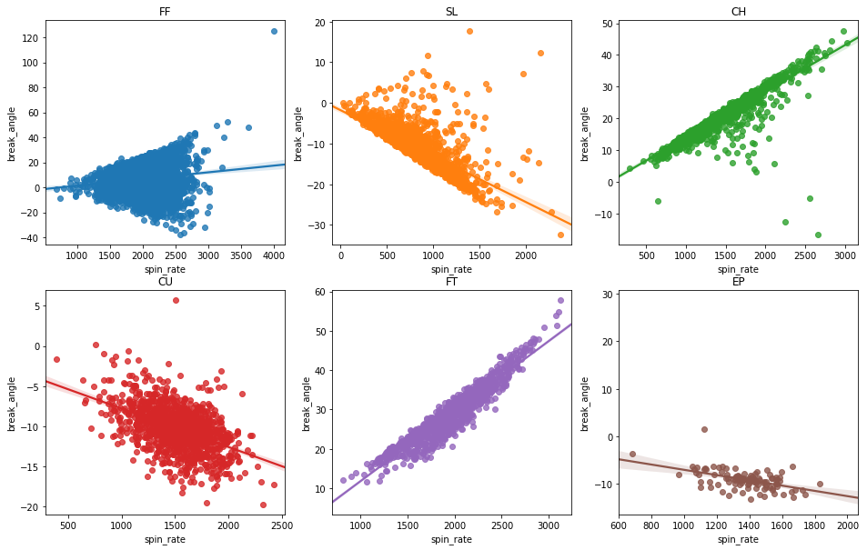

```python
fig, ax = plt.subplots(2,3, figsize = [16,10])

ax = ax.flatten()

ax0 =sb.regplot(data = ff, y = 'break_angle', x = 'spin_rate', ax= ax[0])
ax1 =sb.regplot(data = sl, y = 'break_angle', x = 'spin_rate', ax= ax[1])
ax2 =sb.regplot(data = ch, y = 'break_angle', x = 'spin_rate', ax= ax[2])
ax3 =sb.regplot(data = cu, y = 'break_angle', x = 'spin_rate', ax= ax[3])
ax4 =sb.regplot(data = ft, y = 'break_angle', x = 'spin_rate', ax= ax[4])
ax5 =sb.regplot(data = ep, y = 'break_angle', x = 'spin_rate', ax= ax[5])
ax0.title.set_text('FF')
ax1.title.set_text('SL')
ax2.title.set_text('CH')
ax3.title.set_text('CU')
ax4.title.set_text('FT')
ax5.title.set_text('EP');
```

The fastball correlation is a little odd. It looks like the greater the spin, the greater the angle it moves, but it gets more variable in which direction. The slider, curveball, and eephus all have negative correlations. The less spin, the more movement. Two seam fastballs and change ups have highly positive correlations. These are good things to look at when trying to perfect your pitch as a player.

I want to look at the heat map of the location of each of these pitches. This can show Greinke's tendencies for each of his pitches. I have done a personal project to graph pitches from this dataset so I will be using some of that code.

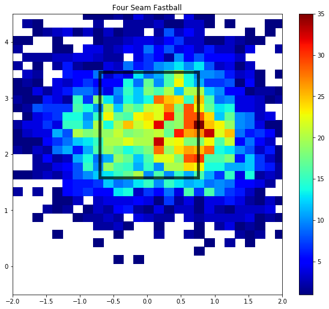

```python
left, width = 0.1, 0.65
bottom, height = 0.1, 0.65
bottom_h = left_h = left + width + 0.02

rect_scatter = [left, bottom, width, height]
#rect_histx = [left, bottom_h, width, 0.2]
#rect_histy = [left_h, bottom, 0.2, height]

plt.figure(1, figsize=(12, 10))

# start with a rectangular Figure

axScatter = plt.axes(rect_scatter)
#axHistx = plt.axes(rect_histx)
#axHisty = plt.axes(rect_histy)
bins_x = np.arange(-2, 0.1+2,0.15)
bins_y = np.arange(-1, 0.1+6, 0.15)
plt.hist2d(data = ff, x = 'px', y = 'pz', bins = [bins_x, bins_y], cmap = 'jet', cmin = 1);
axScatter.set_xlim((-2, 2))
axScatter.set_ylim((-0.5, 4.5))
someX = 0
someY = 3.4632659
axScatter.add_patch(Rectangle((someX - .7083 , someY - 1.8832 ), 1.467, 1.8832, color = 'black',fill=None, alpha=0.7, lw = 5))
plt.colorbar();
plt.title('Four Seam Fastball');
```

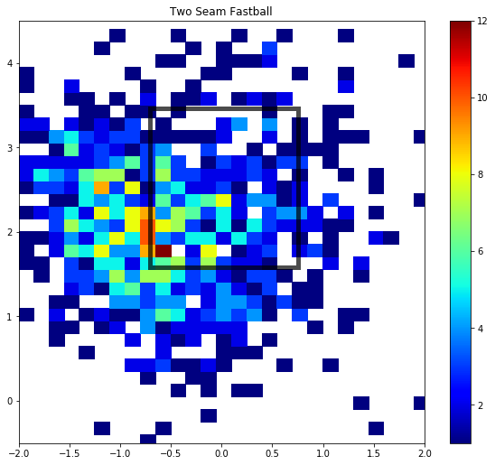

```python
left, width = 0.1, 0.65
bottom, height = 0.1, 0.65
bottom_h = left_h = left + width + 0.02

rect_scatter = [left, bottom, width, height]
#rect_histx = [left, bottom_h, width, 0.2]
#rect_histy = [left_h, bottom, 0.2, height]

plt.figure(1, figsize=(12, 10))

# start with a rectangular Figure


axScatter = plt.axes(rect_scatter)
#axHistx = plt.axes(rect_histx)
#axHisty = plt.axes(rect_histy)
bins_x = np.arange(-2, 0.1+2,0.15)
bins_y = np.arange(-1, 0.1+6, 0.15)
plt.hist2d(data = ft, x = 'px', y = 'pz', bins = [bins_x, bins_y], cmap = 'jet', cmin = 1);
axScatter.set_xlim((-2, 2))
axScatter.set_ylim((-0.5, 4.5))
someX = 0
someY = 3.4632659
axScatter.add_patch(Rectangle((someX - .7083 , someY - 1.8832 ), 1.467, 1.8832, color = 'black',fill=None, alpha=0.7, lw = 5))
plt.colorbar();
plt.title('Two Seam Fastball');
```